# Budweiser Case Study

Kevin Boyd & Scott Frazier

10/6/2021

# Introduction

Our goal was to perform an EDA by identifying errors and recognizing patterns that are present in the beers and breweries data sets given to us by Budweiser. Much of the work consisted of creating visual aids to show insights from the data. We addressed the relationship between alcohol content and the bitterness using multiple plots and methods. We also utilized a k-NN model to address the relationship between ALE and IPA. As a result this EDA shows how some of the most important components of beer relate to each other.

# Load Libraries

```r
library(tidyverse)
library(RColorBrewer)
library(cowplot)
library(class)
library(caret)
library(e1071)
library(stringr)
library(maps)
library(mapproj)
```

# Load in the data

```r
beers <- read.csv("beers.csv", header = T)
breweries <- read.csv("breweries.csv", header = T)
```

# Look at the data

```r
str(beers)
```

```
## 'data.frame':    2410 obs. of  7 variables:
##  $ Name      : chr  "Pub Beer" "Devil's Cup" "Rise of the Phoenix" "Sinister" ...
##  $ Beer_ID   : int  1436 2265 2264 2263 2262 2261 2260 2259 2258 2131 ...
##  $ ABV       : num  0.05 0.066 0.071 0.09 0.075 0.077 0.045 0.065 0.055 0.086 ...
##  $ IBU       : int  NA NA NA NA NA NA NA NA NA NA ...
##  $ Brewery_id: int  409 178 178 178 178 178 178 178 178 178 ...
##  $ Style     : chr  "American Pale Lager" "American Pale Ale (APA)" "American IPA" "American Double / Imperial IPA" ...
##  $ Ounces    : num  12 12 12 12 12 12 12 12 12 12 ...
```

```r
str(breweries)
```

```
## 'data.frame':    558 obs. of  4 variables:
##  $ Brew_ID: int  1 2 3 4 5 6 7 8 9 10 ...
##  $ Name   : chr  "NorthGate Brewing " "Against the Grain Brewery" "Jack's Abby Craft Lagers" "Mike Hess Brewing Company" ...
##  $ City   : chr  "Minneapolis" "Louisville" "Framingham" "San Diego" ...
##  $ State  : chr  " MN" " KY" " MA" " CA" ...
```

```r
head(beers)
```

```
##                  Name Beer_ID   ABV IBU Brewery_id
## 1            Pub Beer    1436 0.050  NA        409
## 2         Devil's Cup    2265 0.066  NA        178
## 3 Rise of the Phoenix    2264 0.071  NA        178
## 4            Sinister    2263 0.090  NA        178
## 5       Sex and Candy    2262 0.075  NA        178
## 6        Black Exodus    2261 0.077  NA        178
##                            Style Ounces
## 1            American Pale Lager     12
## 2        American Pale Ale (APA)     12
## 3                   American IPA     12
## 4 American Double / Imperial IPA     12
## 5                   American IPA     12
## 6                  Oatmeal Stout     12
```

```r
head(breweries)
```

```
##   Brew_ID                      Name          City State
## 1       1        NorthGate Brewing    Minneapolis    MN
## 2       2 Against the Grain Brewery    Louisville    KY
## 3       3  Jack's Abby Craft Lagers    Framingham    MA
## 4       4 Mike Hess Brewing Company     San Diego    CA
## 5       5   Fort Point Beer Company San Francisco    CA
## 6       6     COAST Brewing Company    Charleston    SC
```

# Number 1 - Number of Breweries in Each State

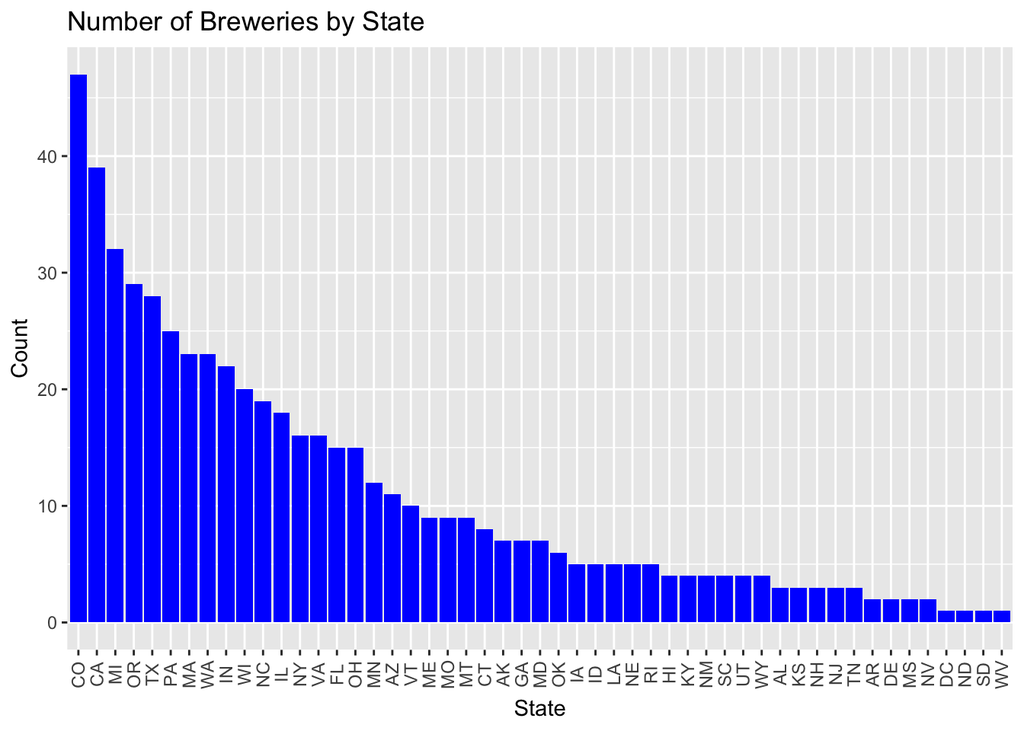

```r
#ordered plot showing counts of breweries per state
brewbystate <- breweries %>%
  group_by(State) %>%
  summarise(count = n()) %>%
  ggplot(aes(x=reorder(State,(-count)), y = count)) +
  geom_bar(stat = "identity",fill="blue") +
  theme(axis.text.x=element_text(angle=90)) +
  ggtitle("Number of Breweries by State") +
  xlab("State") +
  ylab("Count")
brewbystate + theme(axis.text.x=element_text(vjust=0.5))
```

# Number 2 - Merge the Datasets

```r
#merge data sets on Brewery_id
names(breweries)[1] <- "Brewery_id"
df1 <- merge(beers, breweries, by = "Brewery_id", all = T)
names(df1)[2] <- "Beer"
names(df1)[8] <- "Brewery"
str(df1)
```

```
## 'data.frame':    2410 obs. of  10 variables:
##  $ Brewery_id: int  1 1 1 1 1 1 2 2 2 2 ...
##  $ Beer      : chr  "Get Together" "Maggie's Leap" "Wall's End" "Pumpion" ...
##  $ Beer_ID   : int  2692 2691 2690 2689 2688 2687 2686 2685 2684 2683 ...
##  $ ABV       : num  0.045 0.049 0.048 0.06 0.06 0.056 0.08 0.125 0.077 0.042 ...
##  $ IBU       : int  50 26 19 38 25 47 68 80 25 42 ...
##  $ Style     : chr  "American IPA" "Milk / Sweet Stout" "English Brown Ale" "Pumpkin Ale" ...
##  $ Ounces    : num  16 16 16 16 16 16 16 16 16 16 ...
##  $ Brewery   : chr  "NorthGate Brewing " "NorthGate Brewing " "NorthGate Brewing " "NorthGate Brewing " ...
##  $ City      : chr  "Minneapolis" "Minneapolis" "Minneapolis" "Minneapolis" ...
##  $ State     : chr  " MN" " MN" " MN" " MN" ...
```

```r
head(df1)
```

```
##   Brewery_id          Beer Beer_ID   ABV IBU
## 1          1  Get Together    2692 0.045  50
## 2          1 Maggie's Leap    2691 0.049  26
## 3          1    Wall's End    2690 0.048  19
## 4          1       Pumpion    2689 0.060  38
## 5          1    Stronghold    2688 0.060  25
## 6          1   Parapet ESB    2687 0.056  47
##                                 Style Ounces            Brewery        City
## 1                        American IPA     16 NorthGate Brewing  Minneapolis
## 2                  Milk / Sweet Stout     16 NorthGate Brewing  Minneapolis
## 3                   English Brown Ale     16 NorthGate Brewing  Minneapolis
## 4                         Pumpkin Ale     16 NorthGate Brewing  Minneapolis
## 5                     American Porter     16 NorthGate Brewing  Minneapolis
## 6 Extra Special / Strong Bitter (ESB)     16 NorthGate Brewing  Minneapolis
##   State
## 1    MN
## 2    MN
## 3    MN
## 4    MN
## 5    MN
## 6    MN
```

```r
tail(df1)
```

```
##      Brewery_id                      Beer Beer_ID   ABV IBU
## 2405        556             Pilsner Ukiah      98 0.055  NA
## 2406        557  Heinnieweisse Weissebier      52 0.049  NA
## 2407        557           Snapperhead IPA      51 0.068  NA
## 2408        557         Moo Thunder Stout      50 0.049  NA
## 2409        557         Porkslap Pale Ale      49 0.043  NA
## 2410        558 Urban Wilderness Pale Ale      30 0.049  NA
##                        Style Ounces                       Brewery          City
## 2405         German Pilsener     12         Ukiah Brewing Company         Ukiah
## 2406              Hefeweizen     12       Butternuts Beer and Ale Garrattsville
## 2407            American IPA     12       Butternuts Beer and Ale Garrattsville
## 2408      Milk / Sweet Stout     12       Butternuts Beer and Ale Garrattsville
## 2409 American Pale Ale (APA)     12       Butternuts Beer and Ale Garrattsville
## 2410        English Pale Ale     12 Sleeping Lady Brewing Company     Anchorage
##      State
## 2405    CA
## 2406    NY
## 2407    NY
## 2408    NY
## 2409    NY
## 2410    AK
```

# Number 3 - Missing Values

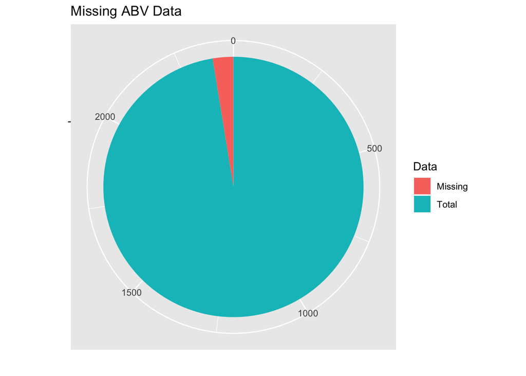

```r
#number of NAs in each data set
Beers_NAs <- sum(is.na(beers))
Brewery_NAs <- sum(is.na(breweries))
NA.df <- data.frame(Measure = c("Beers Data", "Breweries Data"),
                    Value = c(Beers_NAs,Brewery_NAs))
NA.dataset <- ggplot(NA.df, aes(x=Measure, y=Value)) +
  geom_bar(stat = "identity", fill = "red3") +
  ggtitle("Missing Data in each Dataset") +
  xlab("Dataset") +
  ylab("Number of NAs")

#which rows are the NAs coming from?
ABV_NAs <- sum(is.na(beers$ABV))
IBU_NAs <- sum(is.na(beers$IBU))
DataLength <- NROW(beers$ABV)

#make data frame from number of NAs
NA.df1 <- data.frame(Measure = c("ABV","IBU"),
                     Value = c(ABV_NAs,IBU_NAs))

#plot the NA values from each column
NA.column <- ggplot(NA.df1, aes(x=Measure, y=Value)) +
  geom_bar(stat = "identity", fill = "purple2") +
  ggtitle("Missing Data for ABV and IBU") +
  ylab("Number of NAs") +
  xlab("Column in Dataset")

#make a pie chart for ABV
NA.df2 <- data.frame(Measure = c("ABV","ABV"),
                     Data = c("Missing","Total"),
                     Value = c(ABV_NAs,(DataLength-ABV_NAs)))

bp1 <- ggplot(NA.df2, aes(x="", y=Value, fill=Data)) +
  geom_bar(width = 1, stat = "identity") + xlab("") + ylab("") + ggtitle("Missing ABV Data")
pie1 <- bp1 + coord_polar("y", start=0)
pie1
```

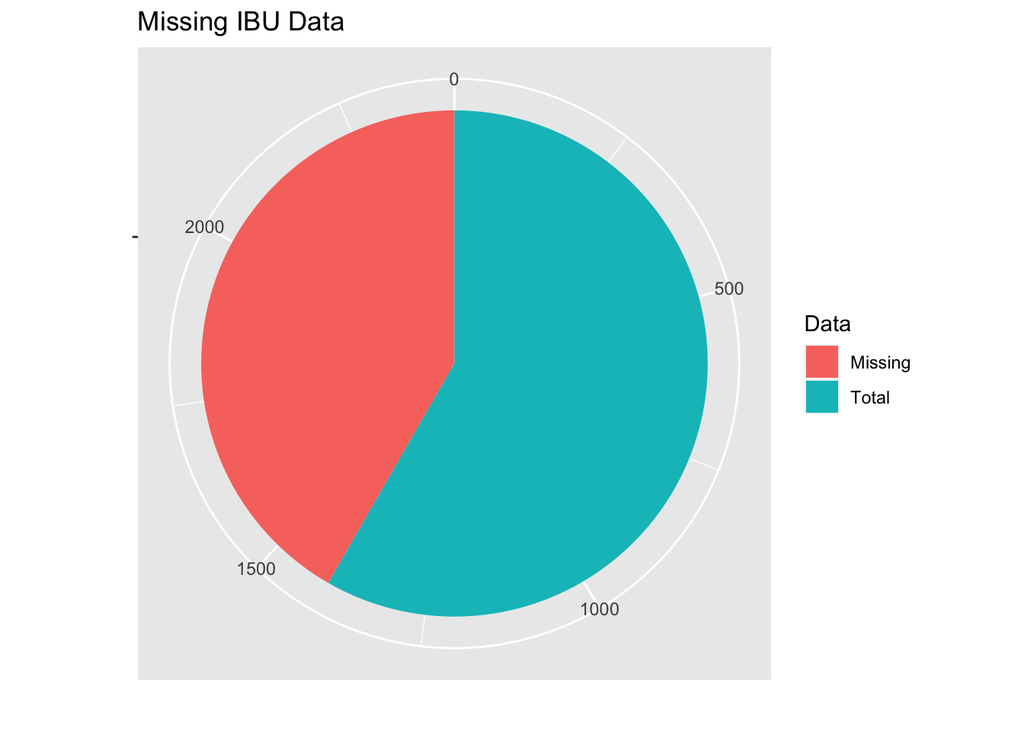

```r
#make pie chart for IBU
NA.df3 <- data.frame(Measure = c("IBU","IBU"),
                     Data = c("Missing","Total"),
                     Value = c(IBU_NAs,(DataLength - IBU_NAs)))

bp2 <- ggplot(NA.df3, aes(x="", y=Value, fill=Data)) +
  geom_bar(width = 1, stat = "identity") + xlab("") + ylab("") + ggtitle("Missing IBU Data")
pie2 <- bp2 + coord_polar("y", start=0)
pie2
```

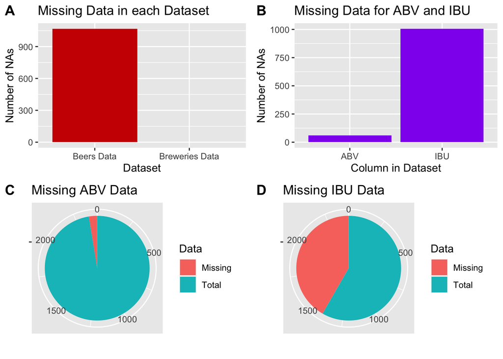

```r
#put all the plots together
NAplots <- plot_grid(NA.dataset,NA.column,pie1,pie2, labels = c("A","B","C","D"))
NAplots
```

# Number 4a - Median ABV by State

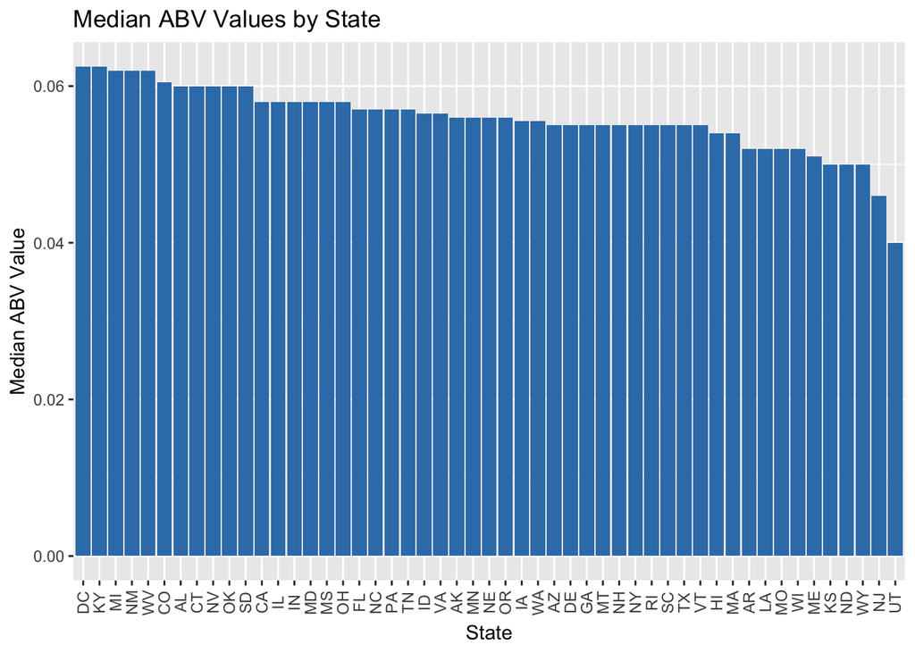

```r
#plot showing the median ABV value per state
ABV_Values <- df1 %>% group_by(State) %>%
  summarize(medianABV = median(ABV, na.rm = T)) %>%
  ggplot(aes(x=reorder(State,(-medianABV)), y=medianABV)) +
  geom_bar(stat = "identity", fill="#377eb8") +
  theme(axis.text.x=element_text(angle=90)) +
  ggtitle("Median ABV Values by State") +
  xlab("State") +
  ylab("Median ABV Value")
ABV_Values + theme(axis.text.x=element_text(vjust=0.5))
```

# Number 4b - Median IBU by State

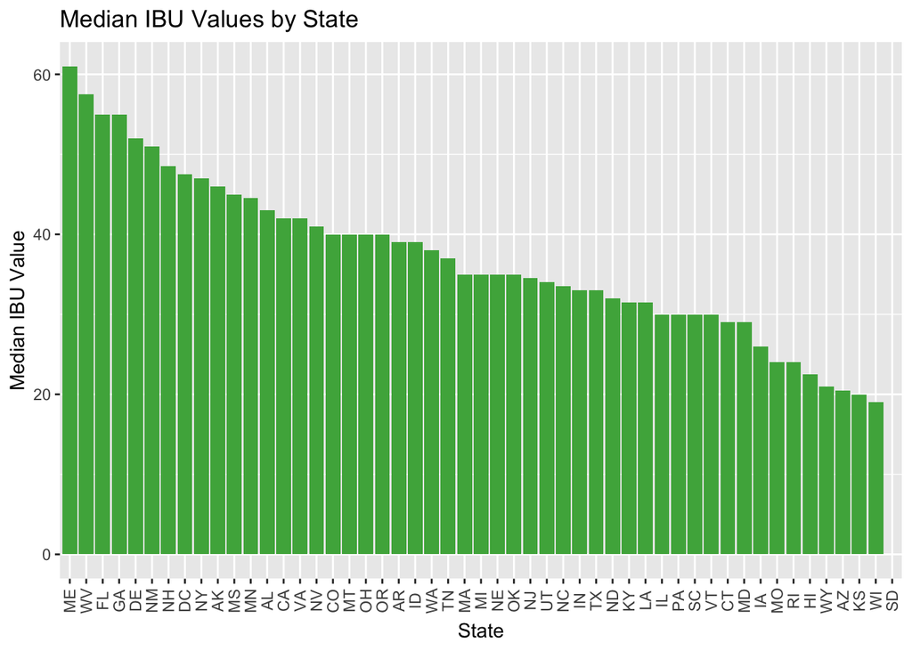

```r
#plot showing the median IBU value per state
IBU_Values <- df1 %>% group_by(State) %>%
  summarize(medianIBU = median(IBU, na.rm = T)) %>%
  ggplot(aes(x=reorder(State,(-medianIBU)), y=medianIBU)) +
  geom_bar(stat = "identity", fill="#4daf4a") +
  theme(axis.text.x=element_text(angle=90)) +
  ggtitle("Median IBU Values by State") +
  xlab("State") +
  ylab("Median IBU Value")
IBU_Values + theme(axis.text.x=element_text(vjust=0.5))
```

# Number 5a - Maximum ABV and IBU

```r
#make data frames with top 5 ABV and IBU values
df2 <- df1[order(df1$ABV,decreasing = T),]
df2 <- df2[c(1,2,3,5,6),c(4,10)]
df3 <- df1[order(df1$IBU,decreasing = T),]
df3 <- df3[c(1:5),c(5,10)]
```

# Number 5b - Top 5 States with Highest IBU

**Oregon has the highest IBU beer**

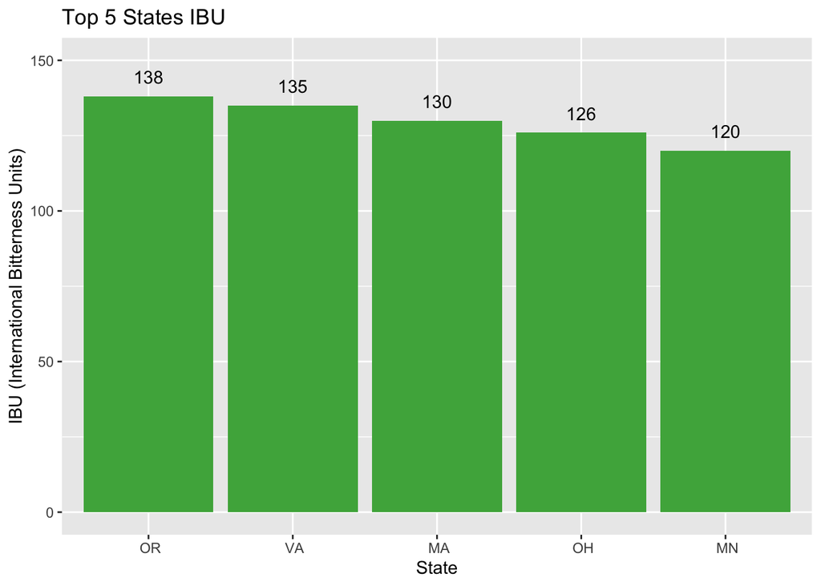

```r
#plot the top 5 states for IBU
ggplot(df3, aes(x = reorder(State, -IBU), y = IBU)) +
  geom_bar(stat = "identity", fill = "#4daf4a") +
  ylim(0,150) +
  ggtitle("Top 5 States IBU") +
  xlab("State") +
  geom_text(aes(label=IBU), vjust=-1) +
  ylab("IBU (International Bitterness Units)")
```

# Number 5c - Top 5 States with Highest ABV

**Colorado has the highest ABV beer**

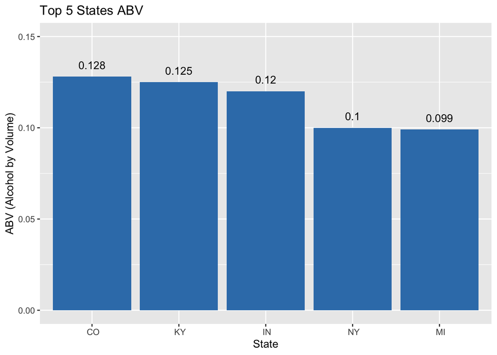

```r
#plot the top states for ABV
ggplot(df2, aes(x = reorder(State, -ABV), y = ABV)) +
  geom_bar(stat = "identity", fill= "#377eb8") +
  ylim(0,0.15) +
  ggtitle("Top 5 States ABV") +
  xlab("State") +
  geom_text(aes(label=ABV), vjust=-1) +
  ylab("ABV (Alcohol by Volume)")
```

# Number 6 - Distribution of ABV

**The evidence suggests the distribution of ABV is right skewed with a median value of 0.056 with a mean of 0.0598. There are a number of values greater than 0.1 that make it appear to be right skewed.**

```r
#Summary stats of ABV
summary(df1$ABV)
```

```
##    Min. 1st Qu.  Median    Mean 3rd Qu.    Max.    NA's
## 0.00100 0.05000 0.05600 0.05977 0.06700 0.12800      62
```

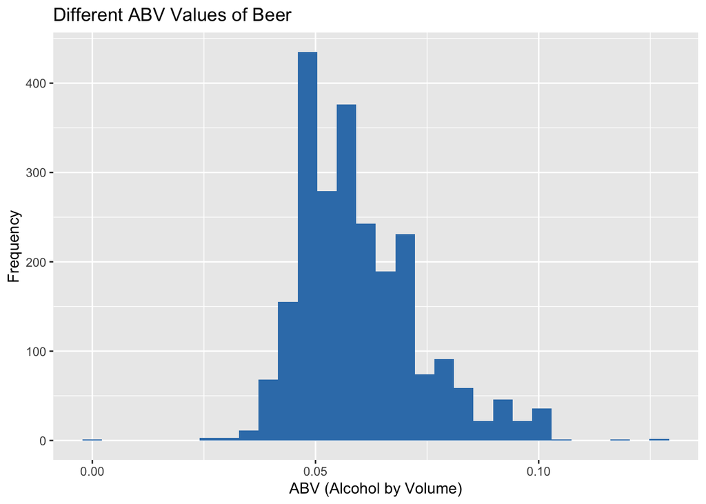

```r
#Distributions
#Histogram of ABV in df1
df1 %>% ggplot(aes(x=ABV)) + geom_histogram(fill = "#377eb8") + ggtitle("Different ABV Values of Beer") + labs(x="ABV (Alcohol by Volume)", y="Frequency")
```

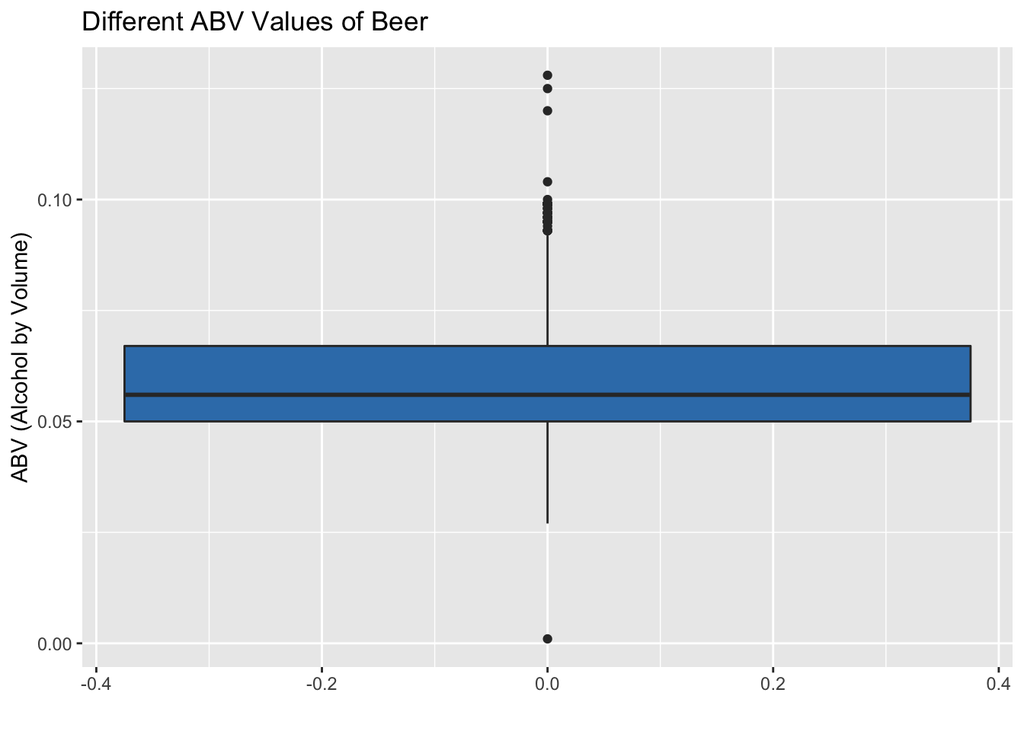

```r
#boxplot
df1 %>% ggplot(aes(x=ABV)) + geom_boxplot(fill = "#377eb8") + ggtitle("Different ABV Values of Beer") + labs(x="ABV (Alcohol by Volume)", y="") + coord_flip()
```

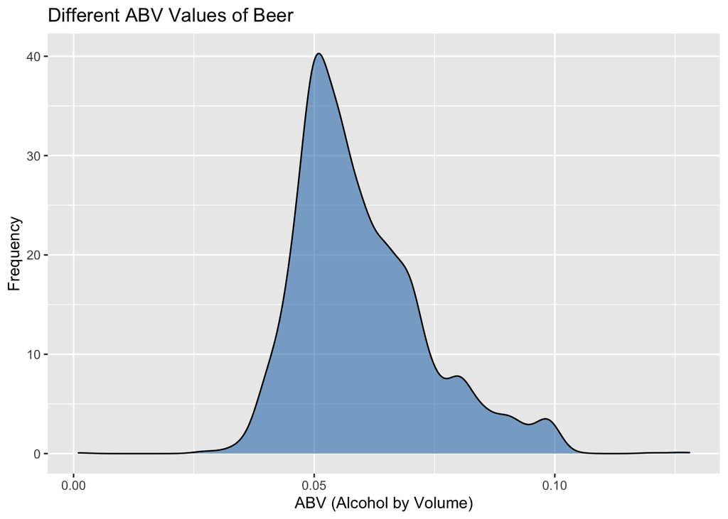

```r
#geom_density
ABV_vizz = ggplot(df1, aes(x = ABV))

ABV_vizz + geom_density(fill = "#377eb8", alpha=0.6) +
  geom_vline(aes(xintercept = mean(ABV)),
             linetype = "dashed", size = 0.6,
             color = "#FC4E07") +
  ylab("Frequency") +
  ggtitle("Different ABV Values of Beer") +
  xlab("ABV (Alcohol by Volume)")
```

# Number 7 - Relationship between ABV and IBU

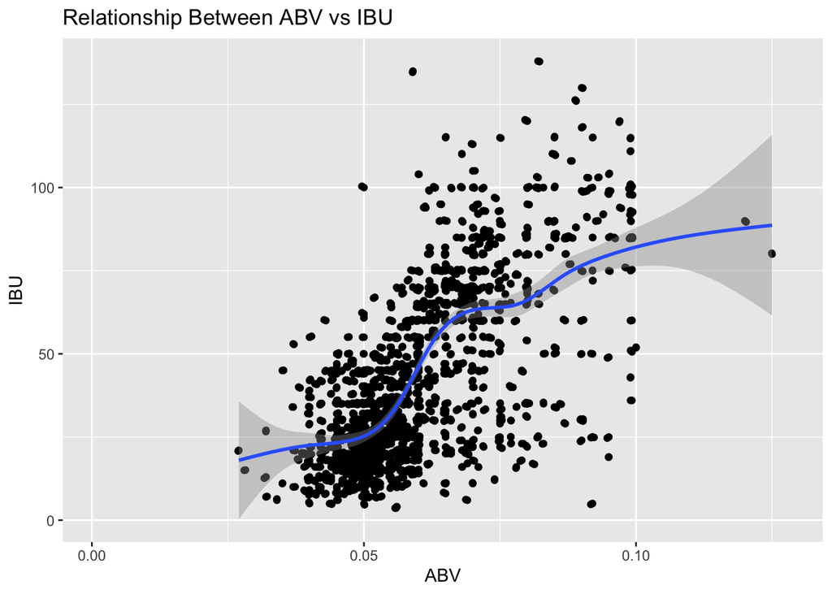

```r
ggplot(df1, aes(x=ABV, y=IBU)) +
  geom_point() +
  geom_jitter() +
  geom_smooth() +
  ggtitle("Relationship Between ABV vs IBU")
```

# Number 8a - k-NN Model

```r
#Make new column with ALE, IPA, or Other as identifier
df1$Type = ifelse(grepl("\\bale\\b", df1$Style, ignore.case = T), "ALE",
                  ifelse(grepl("\\bipa\\b", df1$Style, ignore.case = T), "IPA", "Other"))
head(df1)
```

```
##   Brewery_id          Beer Beer_ID   ABV IBU
## 1          1  Get Together    2692 0.045  50
## 2          1 Maggie's Leap    2691 0.049  26
## 3          1    Wall's End    2690 0.048  19
## 4          1       Pumpion    2689 0.060  38
## 5          1    Stronghold    2688 0.060  25
## 6          1   Parapet ESB    2687 0.056  47
##                                 Style Ounces            Brewery        City
## 1                        American IPA     16 NorthGate Brewing  Minneapolis
## 2                  Milk / Sweet Stout     16 NorthGate Brewing  Minneapolis
## 3                   English Brown Ale     16 NorthGate Brewing  Minneapolis
## 4                         Pumpkin Ale     16 NorthGate Brewing  Minneapolis
## 5                     American Porter     16 NorthGate Brewing  Minneapolis
## 6 Extra Special / Strong Bitter (ESB)     16 NorthGate Brewing  Minneapolis
##   State  Type
## 1    MN   IPA
## 2    MN Other
## 3    MN   ALE
## 4    MN   ALE
## 5    MN Other
## 6    MN Other
```

```r
#Make new data frame with only Ale beers
aleIPA <- df1 %>% filter(df1$Type == "ALE" | df1$Type == "IPA")
head(aleIPA)
```

```
##   Brewery_id           Beer Beer_ID   ABV IBU                          Style
## 1          1   Get Together    2692 0.045  50                   American IPA
## 2          1     Wall's End    2690 0.048  19              English Brown Ale
## 3          1        Pumpion    2689 0.060  38                    Pumpkin Ale
## 4          2 Citra Ass Down    2686 0.080  68 American Double / Imperial IPA
## 5          2         A Beer    2683 0.042  42        American Pale Ale (APA)
## 6          2  Flesh Gourd'n    2681 0.066  21                    Pumpkin Ale
##   Ounces                   Brewery        City State Type
## 1     16        NorthGate Brewing  Minneapolis    MN  IPA
## 2     16        NorthGate Brewing  Minneapolis    MN  ALE
## 3     16        NorthGate Brewing  Minneapolis    MN  ALE
## 4     16 Against the Grain Brewery  Louisville    KY  IPA
## 5     16 Against the Grain Brewery  Louisville    KY  ALE
## 6     16 Against the Grain Brewery  Louisville    KY  ALE
```

```r
#Make training and test data frames
splitPerc <- .7
trainIndices <- sample(1:dim(aleIPA)[1],round(splitPerc * dim(aleIPA)[1]))
dfTrain <- aleIPA[trainIndices,]
dfTest <- aleIPA[-trainIndices,]

#Omit the NAs
dfTrain <- na.omit(dfTrain)
dfTest <- na.omit(dfTest)

#knn model
classifications <- knn(dfTrain[,4:5], dfTest[,4:5], dfTrain$Type, k = 10, prob = TRUE)
table(dfTest$Type,classifications)
```

```
##      classifications
##       ALE IPA
##   ALE 133  27
##   IPA  25 102
```

```r
confusionMatrix(table(dfTest$Type,classifications))
```

```
## Confusion Matrix and Statistics
##
##      classifications
##       ALE IPA
##   ALE 133  27
##   IPA  25 102
##
##                Accuracy : 0.8188
##                  95% CI : (0.7693, 0.8616)
##     No Information Rate : 0.5505
##     P-Value [Acc > NIR] : <2e-16
##
##                   Kappa : 0.6334
##
##  Mcnemar's Test P-Value : 0.8897
##
##             Sensitivity : 0.8418
##             Specificity : 0.7907
##          Pos Pred Value : 0.8312
##          Neg Pred Value : 0.8031
##              Prevalence : 0.5505
##          Detection Rate : 0.4634
##    Detection Prevalence : 0.5575
##       Balanced Accuracy : 0.8162
##
##        'Positive' Class : ALE
##
```

# Number 8b - Find Best k Value

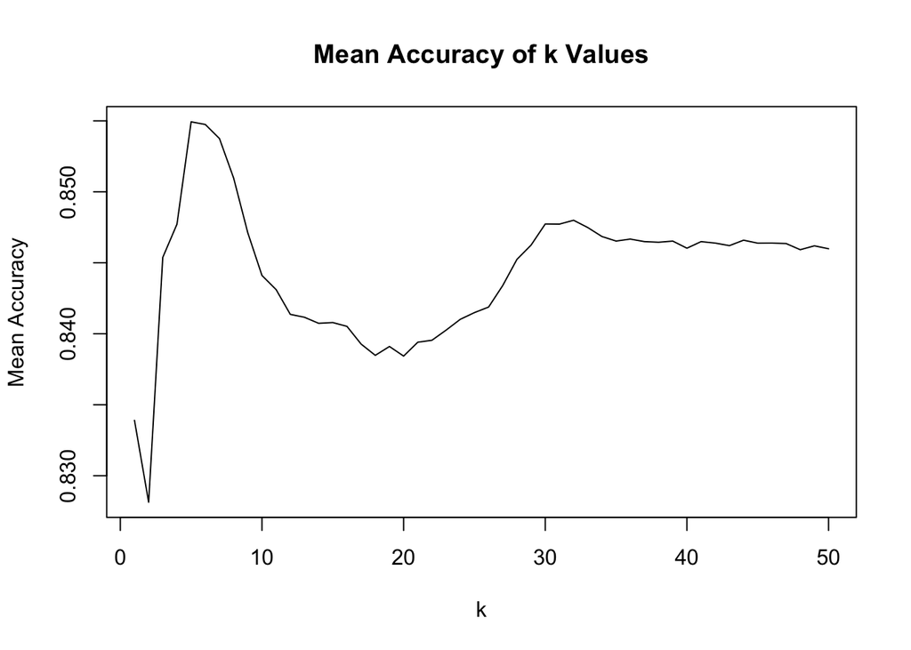

```r
#Loop for many k and the average of many training / test partition
iterations = 100
numks = 50

masterAcc = matrix(nrow = iterations, ncol = numks)

for(j in 1:iterations)
{
  accs = data.frame(accuracy = numeric(100), k = numeric(100))
  trainIndices = sample(1:dim(aleIPA)[1],round(splitPerc * dim(aleIPA)[1]))
  train = aleIPA[trainIndices,]
  test = aleIPA[-trainIndices,]
  train = na.omit(train)
  test = na.omit(test)
  for(i in 1:numks)
  {
    classifications = knn(train[,c(4,5)],test[,c(4,5)],train$Type, prob = TRUE, k = i)
    table(classifications,test$Type)
    CM = confusionMatrix(table(classifications,test$Type))
    masterAcc[j,i] = CM$overall[1]
  }

}

MeanAcc = colMeans(masterAcc)

plot(seq(1,numks,1),MeanAcc, type = "l", xlab = "k", ylab = "Mean Accuracy", main = "Mean Accuracy of k Values")
```

# Number 8c - k-NN Model with Optimized k

```r
#k-NN model using best value of k
classifications4 <- knn(dfTrain[,4:5], dfTest[,4:5], dfTrain$Type, k = 6, prob = TRUE)
table(dfTest$Type,classifications4)
```

```
##      classifications4
##       ALE IPA
##   ALE 137  23
##   IPA  19 108
```

```r
confusionMatrix(table(dfTest$Type,classifications4))
```

```
## Confusion Matrix and Statistics
##
##      classifications4
##       ALE IPA
##   ALE 137  23
##   IPA  19 108
##
##                Accuracy : 0.8537
##                  95% CI : (0.8074, 0.8925)
##     No Information Rate : 0.5436
##     P-Value [Acc > NIR] : <2e-16
##
##                   Kappa : 0.7044
##
##  Mcnemar's Test P-Value : 0.6434
##
##             Sensitivity : 0.8782
##             Specificity : 0.8244
##          Pos Pred Value : 0.8562
##          Neg Pred Value : 0.8504
##              Prevalence : 0.5436
##          Detection Rate : 0.4774
##    Detection Prevalence : 0.5575
##       Balanced Accuracy : 0.8513
##
##        'Positive' Class : ALE
##
```

# Number 8d - Test ABV & IBU Contribution to Model Accuracy

**Both ABV and IBU allowed high accuracy in our model predicting if a beer is considered an IPA, but IBU was the best measure in the model.**

```r
#knn internal model for ABV and IBU
classifications1 <- knn.cv(dfTrain[,4:5],dfTrain$Type, k = 10)
confusionMatrix(table(classifications1,dfTrain$Type))
```

```
## Confusion Matrix and Statistics
##
##
## classifications1 ALE IPA
##              ALE 353  60
##              IPA  46 198
##
##                Accuracy : 0.8387
##                  95% CI : (0.8083, 0.866)
##     No Information Rate : 0.6073
##     P-Value [Acc > NIR] : <2e-16
##
##                   Kappa : 0.6585
##
##  Mcnemar's Test P-Value : 0.2067
##
##             Sensitivity : 0.8847
##             Specificity : 0.7674
##          Pos Pred Value : 0.8547
##          Neg Pred Value : 0.8115
##              Prevalence : 0.6073
##          Detection Rate : 0.5373
##    Detection Prevalence : 0.6286
##       Balanced Accuracy : 0.8261
##
##        'Positive' Class : ALE
##
```

```r
#knn model for ABV
classifications2 <- knn.cv(dfTrain[,4],dfTrain$Type, k = 10)
confusionMatrix(table(classifications2,dfTrain$Type))
```

```
## Confusion Matrix and Statistics
##
##
## classifications2 ALE IPA
##              ALE 312  75
##              IPA  87 183
##
##                Accuracy : 0.7534
##                  95% CI : (0.7186, 0.7859)
##     No Information Rate : 0.6073
##     P-Value [Acc > NIR] : 1.788e-15
##
##                   Kappa : 0.4873
##
##  Mcnemar's Test P-Value : 0.3875
##
##             Sensitivity : 0.7820
##             Specificity : 0.7093
##          Pos Pred Value : 0.8062
##          Neg Pred Value : 0.6778
##              Prevalence : 0.6073
##          Detection Rate : 0.4749
##    Detection Prevalence : 0.5890
##       Balanced Accuracy : 0.7456
##
##        'Positive' Class : ALE
##
```

```r
#knn model for IBU
classifications3 <- knn.cv(dfTrain[,5],dfTrain$Type, k = 10)
confusionMatrix(table(classifications3,dfTrain$Type))
```

```
## Confusion Matrix and Statistics
##
##
## classifications3 ALE IPA
##              ALE 344  49
##              IPA  55 209
##
##                Accuracy : 0.8417
##                  95% CI : (0.8115, 0.8688)
##     No Information Rate : 0.6073
##     P-Value [Acc > NIR] : <2e-16
##
##                   Kappa : 0.6695
##
##  Mcnemar's Test P-Value : 0.6239
##
##             Sensitivity : 0.8622
##             Specificity : 0.8101
##          Pos Pred Value : 0.8753
##          Neg Pred Value : 0.7917
##              Prevalence : 0.6073
##          Detection Rate : 0.5236
##    Detection Prevalence : 0.5982
##       Balanced Accuracy : 0.8361
##
##        'Positive' Class : ALE
##
```

# Number 9a - Interesting Relationships

```r
# make new column with beer identifiers and make into a factor
df1$New <- ifelse(grepl("\\bale\\b", df1$Style, ignore.case = T), "ALE",
                  ifelse(grepl("\\bipa\\b", df1$Style, ignore.case = T), "IPA",
                         ifelse(grepl("\\bWheat\\b", df1$Style, ignore.case = T), "Wheat",
                                ifelse(grepl("\\bAmber\\b", df1$Style, ignore.case = T), "Amber",
                                       ifelse(grepl("\\bStout\\b", df1$ Style, ignore.case = T), "Stout",
                                              ifelse(grepl("\\bLager\\b", df1$Style, ignore.case = T), "Lager",
                                                     ifelse(grepl("\\bPorter\\b", df1$Style, ignore.case = T), "Porter",
                                                            ifelse(grepl("\\bPilsner\\b", df1$Style, ignore.case = T), "Pilsner",
                                                                   "Other"))))))))
head(df1)
```

```
##   Brewery_id          Beer Beer_ID   ABV IBU
## 1          1  Get Together    2692 0.045  50
## 2          1 Maggie's Leap    2691 0.049  26
## 3          1    Wall's End    2690 0.048  19
## 4          1       Pumpion    2689 0.060  38
## 5          1    Stronghold    2688 0.060  25
## 6          1   Parapet ESB    2687 0.056  47
##                                 Style Ounces            Brewery        City
## 1                        American IPA     16 NorthGate Brewing  Minneapolis
## 2                  Milk / Sweet Stout     16 NorthGate Brewing  Minneapolis
## 3                   English Brown Ale     16 NorthGate Brewing  Minneapolis
## 4                         Pumpkin Ale     16 NorthGate Brewing  Minneapolis
## 5                     American Porter     16 NorthGate Brewing  Minneapolis
## 6 Extra Special / Strong Bitter (ESB)     16 NorthGate Brewing  Minneapolis
##   State  Type    New
## 1    MN   IPA    IPA
## 2    MN Other  Stout
## 3    MN   ALE    ALE
## 4    MN   ALE    ALE
## 5    MN Other Porter
## 6    MN Other  Other
```

```r
df1$New <- as.factor(df1$New)
str(df1)
```

```
## 'data.frame':    2410 obs. of  12 variables:
##  $ Brewery_id: int  1 1 1 1 1 1 2 2 2 2 ...
##  $ Beer      : chr  "Get Together" "Maggie's Leap" "Wall's End" "Pumpion" ...
##  $ Beer_ID   : int  2692 2691 2690 2689 2688 2687 2686 2685 2684 2683 ...
##  $ ABV       : num  0.045 0.049 0.048 0.06 0.06 0.056 0.08 0.125 0.077 0.042 ...
##  $ IBU       : int  50 26 19 38 25 47 68 80 25 42 ...
##  $ Style     : chr  "American IPA" "Milk / Sweet Stout" "English Brown Ale" "Pumpkin Ale" ...
##  $ Ounces    : num  16 16 16 16 16 16 16 16 16 16 ...
##  $ Brewery   : chr  "NorthGate Brewing " "NorthGate Brewing " "NorthGate Brewing " "NorthGate Brewing " ...
##  $ City      : chr  "Minneapolis" "Minneapolis" "Minneapolis" "Minneapolis" ...
##  $ State     : chr  " MN" " MN" " MN" " MN" ...
##  $ Type      : chr  "IPA" "Other" "ALE" "ALE" ...
##  $ New       : Factor w/ 8 levels "ALE","Amber",..: 3 8 1 1 7 5 3 5 8 1 ...
```

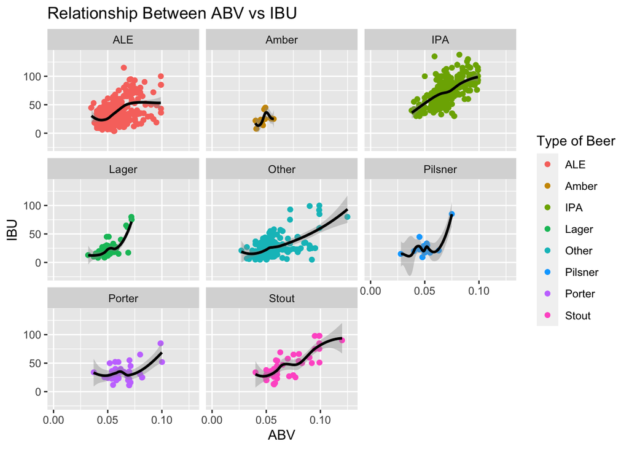

```r
#plot each beer ABV and IBU individually
ggplot(df1, aes(x=ABV, y=IBU, color=New)) +
  geom_point() +
  geom_jitter() +
  geom_smooth(color="black") +
  ggtitle("Relationship Between ABV vs IBU") +
  labs(color="Type of Beer") +
  facet_wrap(~New)
```

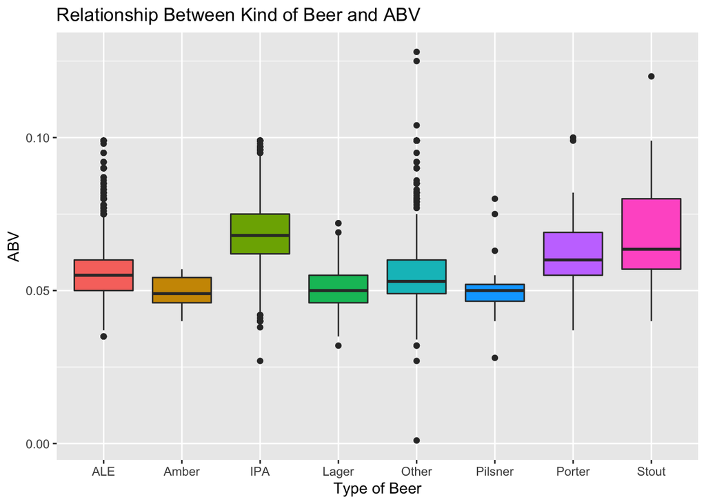

```r
#boxplot for ABV of each beer
p1 <- ggplot(df1, aes(x=New, y=ABV, fill=New)) +
  geom_boxplot() +
  ggtitle("Relationship Between Kind of Beer and ABV") +
  xlab("Type of Beer") +
  theme(legend.position="none")
p1
```

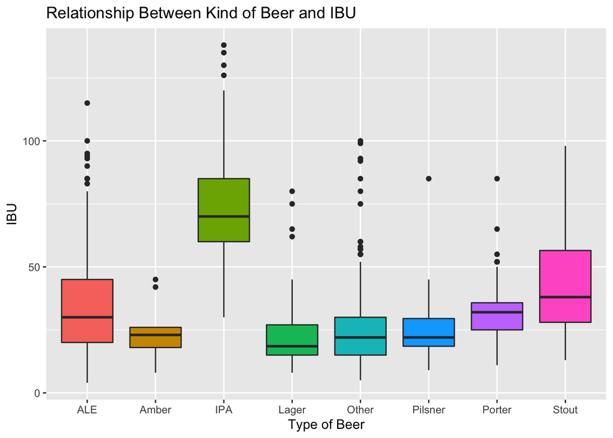

```r
#boxplot for IBU of each beer
p2 <- ggplot(df1, aes(x=New, y=IBU, fill=New)) +
  geom_boxplot() +
  ggtitle("Relationship Between Kind of Beer and IBU") +
  xlab("Type of Beer") +
  theme(legend.position="none")
p2
```